# Assignment 2 - Due Tuesday, February 3rd at 8am ET

Complete the code cells in this Jupyter notebook, and submit the final .ipynb notebook to Gradescope

- Make sure you save your changes in VS Code before uploading it (beware of the little "dot" in the tab above)
- You should **execute all code cells** before saving and submitting. We need to see the outputs/figures generated by Python

**(Q1)** Import the `pandas` and `matplotlib.pyplot` packages. You can give them aliases (nicknames) if you choose, but this is not required.

```python
# Write your answer

import pandas as pd
import matplotlib.pyplot as plt
```

**(Q2)** Using `pandas`, read in the data from "us_emission.csv" that is saved in the subfolder named "data".

- Assign it to a variable named "us_emissions"
- Do **not** move the file "us_emission.csv" out of the subfolder, or move the .ipynb file into the subfolder.
- For reference, all the files in the "data" subfolder was taken from the following source:[Kaggle: Countries CO2 Emission and more...](https://www.kaggle.com/datasets/lobosi/c02-emission-by-countrys-grouth-and-population)

```python
# Write your answer
US_EMIS_PATH = "data/us_emission.csv"

us_emissions = pd.read_csv(US_EMIS_PATH)
us_emissions.head()
```

|  | Year | Energy_consumption | CO2_emission | GDP |
| --- | --- | --- | --- | --- |
| 0 | 1993 | 174.507427 | 10187.758796 | 62549.22 |
| 1 | 1994 | 177.864578 | 10371.040316 | 65068.92 |
| 2 | 1995 | 181.783814 | 10525.326666 | 66815.52 |
| 3 | 1996 | 187.793221 | 10648.622798 | 69336.12 |
| 4 | 1997 | 188.957916 | 11036.060088 | 72419.64 |

**(Q3)** View the dataset and create a list of variable names

- View the data contained in `us_emissions` using the Data Wrangler extension. You will see four column headings.
- Define a **list** containing four strings, one for each of the column headings.
- The strings must match the headings **exactly** (the "#" symbols shown in Data Wrangler are not part of the name). Otherwise you will run into a problem in (Q4)
- Assign this list to a variable named `columns`
- You do not have to "extract" the names from the dataset through a Python command. You can simply type them manually.

```python
# Write your answer

columns = []
for col in us_emissions.columns:
    columns.append(col)

#chose to do this with a loop, could easily manually type it out but this is better for longer dataframes
```

**(Q4)** Compute descriptive statistics for the 3rd variable "CO2_emission" in the dataset.

- The direct way to do this is to execute the command:

  ```
      us_emissions["CO2_emission"].describe()
  ```

- Do something similar in the code cell below, but typing the string "CO2_emission" is **not allowed**
- Instead of typing "CO2_emission" manually, use the variable "columns" you created in the previous cell, extracting the list's 3rd element
- **Remember:** The numbering in Python starts at zero
- For example, if

  ```
      list_colors = ["red", "green", "yellow", "indigo"]
  ```

  then `list_colors[3]` will be the string `"indigo"`

```python
# Write your answer

us_emissions[columns[2]].describe()
```

```
count       27.000000
mean     11092.828455
std        603.034917
min      10187.758796
25%      10539.856087
50%      11036.060088
75%      11643.151938
max      12031.075854
Name: CO2_emission, dtype: float64
```

**Hint:** If you did everything correctly above, that cell should have the same output as the one below

```python
# run this cell to compare with your answer above
us_emissions["CO2_emission"].describe()
```

```
count       27.000000
mean     11092.828455
std        603.034917
min      10187.758796
25%      10539.856087
50%      11036.060088
75%      11643.151938
max      12031.075854
Name: CO2_emission, dtype: float64
```

**(Q5)** Choose another country from the "data" subfolder and import the data as you did in (Q2). Using the data, create a **scatter plot** of "Energy Consumption" vs. "CO2 Emissions".

- Whenever we say to plot "Variable 1" vs. "Variable 2", we mean the x-axis (horizontal axis) corresponds to "Variable 1" and the y-axis (vertical axis) corresponds to "Variable 2".
- For **full points**, label both axes in the plot. The labels should clearly indicate what variables are being plotted.
- Use `plt.title` to create a title for the plot. It should specify which country the data corresponds to and what information is being displayed.
- Use `plt.show()` after creating the plot to ensure extraneous output is not displayed

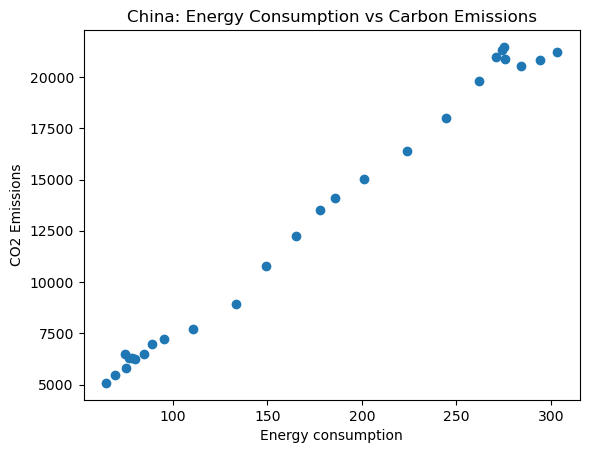

```python
# Write your answer
CHINA_EMIS_PATH = "data/china_emission.csv"

china_df = pd.read_csv(CHINA_EMIS_PATH)

plt.scatter(china_df[columns[1]], china_df[columns[2]])
plt.xlabel("Energy consumption")
plt.ylabel("CO2 Emissions")
plt.title("China: Energy Consumption vs Carbon Emissions")
plt.show()
```

**(Q6)** Choose any 2 of the countries in the "data" subfolder and import the 2 datasets as you did in (Q2). Create **two separate** scatter plots that plots "Year" vs. "CO2 emissions".

- For full points, label the axes in **both** plots. The labels should clearly indicate what variables are being plotted.
- Use `plt.title` to create a title for **both** plots. The titles should specify which country the data corresponds to and what information is being displayed.
- Execute `plt.show()` after creating each plot to ensure both are displayed in the output window.

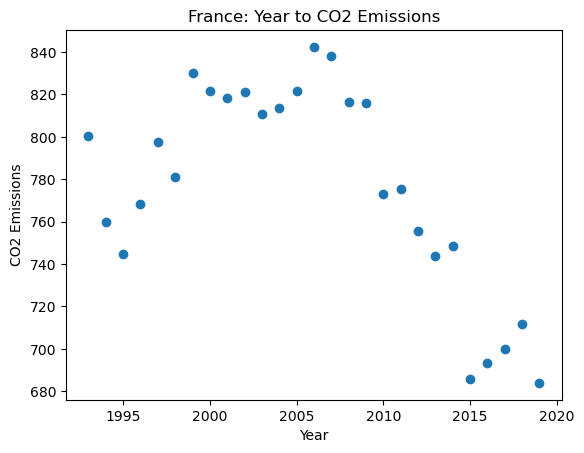

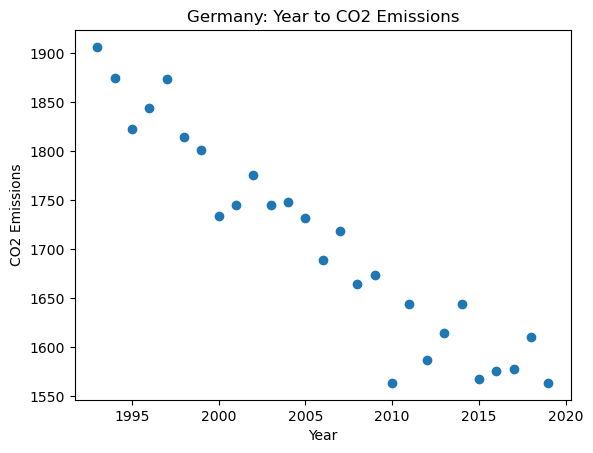

```python
# Write your answer

FRANCE_EMIS_PATH = "data/france_emission.csv"
GERMANY_EMIS_PATH = "data/germany_emission.csv"

france_df = pd.read_csv(FRANCE_EMIS_PATH)
germany_df = pd.read_csv(GERMANY_EMIS_PATH)
nation_lis = [("France", france_df), ("Germany", germany_df)]

for nation, nation_df in nation_lis:
    plt.scatter(nation_df[columns[0]], nation_df[columns[2]])
    plt.xlabel("Year")
    plt.ylabel("CO2 Emissions")
    plt.title(f"{nation}: Year to CO2 Emissions")
    plt.show()
```